# Short-Video Watching Behaviour and Daily Viewing Patterns

## Introduction

This visual data story explores patterns in short-video watching behaviour through observational logging data collected using a Google Form.

The project focuses on how viewing behaviour changes across different daily activities, platforms, and times of day.

## Watching Behaviour Before Different Activities

The first visualisation compares the average number of short videos watched across different activities before watching.

The visualisation that the highest average number of videos was recorded during sessions that occurred before sleeping and while commuting. In contrast, eating and studying sessions were associated with lower average amount.

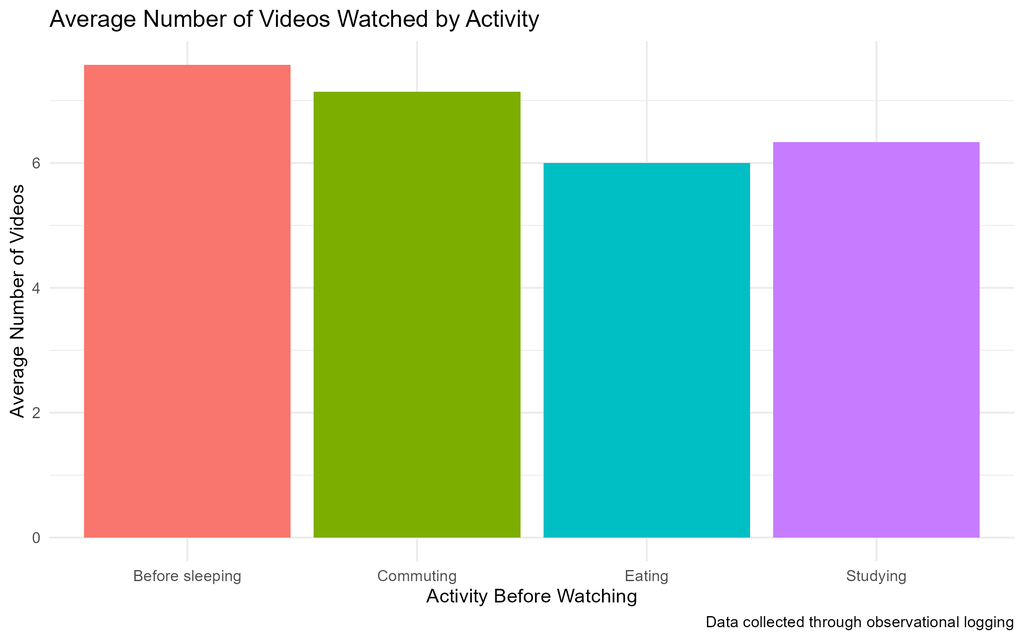

Bar chart showing average number of videos watched across different activities including studying, commuting, eating, and before sleeping.

## Platform Usage Throughout the Day

The second visualisation shows how different short-video platforms were used during different hours of the day.

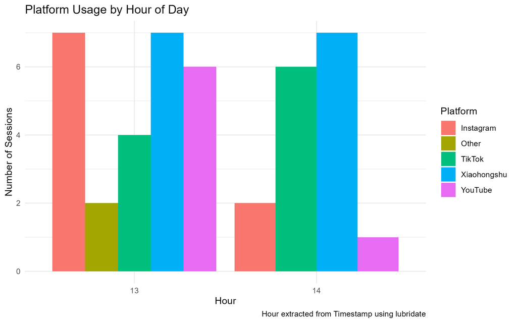

Bar chart showing the frequency of different platform usage across different hours of the day.

## Session Ratings Across Different Times of Day

The final visualisation uses a boxplot to compare session ratings across different times of day.

Evening and late-night sessions generally showed higher, with many observations concentrated in the upper part of the scale. Afternoon sessions also tended to receive relatively high ratings, although one lower-rating outlier existed.

The distribution of sessions in the morning is more balanced, with the median closer to the center of the box plot.

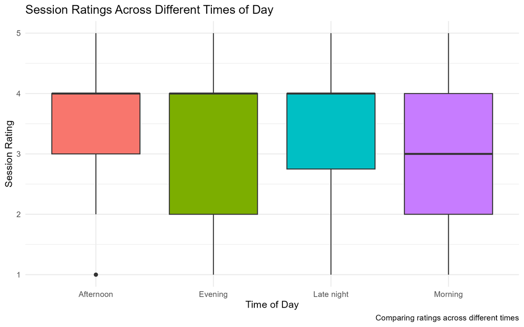

Boxplot comparing session ratings for morning, afternoon, evening, and late-night viewing sessions.

## Conclusion

Overall, the observational logging data suggests that short-video watching behaviour varies depending on activity, platform, and time of day.

The visualisations highlight patterns in viewing behaviour and demonstrate how observational data can be used to explore everyday digital media habits.